# Project_5310

Malik Awan, Jas Sur

11/18/2020

## Red To Green Move

We came up with a day trading strategy which we want to test; strategy is simple. Any FAANG stock that opens up few percent below the previous closing price, will rally back to the previous closing price. FAANG is an acronym that refers to five prominent publicly traded American technology companies: Facebook (FB), Amazon (AMZN), Apple (AAPL), Netflix (NFLX); and Alphabet (GOOG) (formerly known as Google). for example, if Apple’s closing price on Monday was 100 and Tuesday opening price is 99, which is 1% below the Monday’s closing price, according to our strategy, the probability of stock going back to 100, at least for a moment, is very high. Since it’s a day trade, we buy at the open and sell at the previous closing price. For this analysis, we are going to use change percentage, volume, and 3 technical indicators Moving-Averages, Bollinger-bands, and Relative-strength-index. We will explain each of the technical indicators as we move forward with our analysis. We are going to use historic stock price data live from the source “yahoo”.

```r
current_date <- format(Sys.time(), "%Y-%m-%d")
facebook <- getSymbols("FB", src = "yahoo", from = "2013-01-01", to = current_date, auto.assign = FALSE)
```

[output not shown]

```r
head(facebook)
```

```
##            FB.Open FB.High FB.Low FB.Close FB.Volume FB.Adjusted
## 2013-01-02   27.44   28.18  27.42    28.00  69846400       28.00
## 2013-01-03   27.88   28.47  27.59    27.77  63140600       27.77
## 2013-01-04   28.01   28.93  27.83    28.76  72715400       28.76
## 2013-01-07   28.69   29.79  28.65    29.42  83781800       29.42
## 2013-01-08   29.51   29.60  28.86    29.06  45871300       29.06
## 2013-01-09   29.67   30.60  29.49    30.59 104787700       30.59
```

#### Lets quickly visualize our data. We are going to use candlestick chart for the month of Jan and Feb 2020.

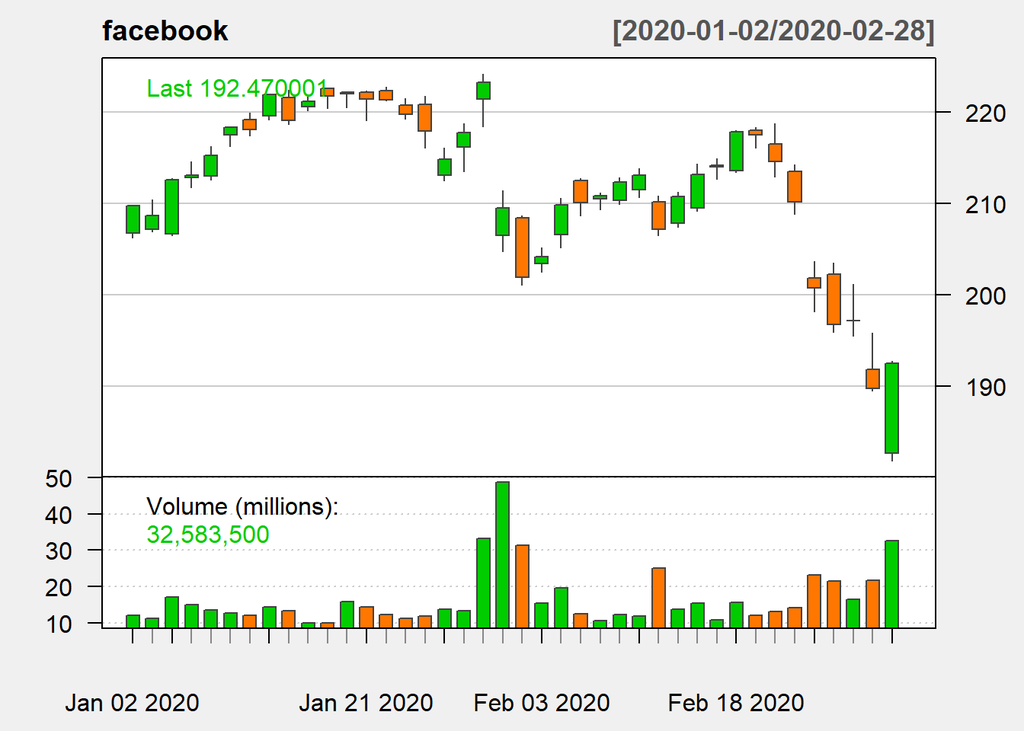

```r
candleChart(facebook, TA=c(addVo()), subset = '2020-01::2020-02', theme = "white") ## candleChart is a function of quantmod library .TA allows for the inclusion of a variety of chart overlays and tecnical indicators.. In this particular Chart, we are adding volume at the bottom.
```

**Each candlestick represent single day. Length of the candle represents high and the low of the day. Candle will be green if it closes above the open price and orange or red if it closes below the open price of the same day. At the bottom of the chart, we have volume in millions. here is a link to understand candlestick in details https://www.investopedia.com/trading/candlestick-charting-what-is-it/**

## Moving Averages

#### Moving averages are one of the most common techincal indicators in stocks. It helps analysts identify trends in price fluctuations. Let’s add Moving averages to our Dataframe and Visualize it.

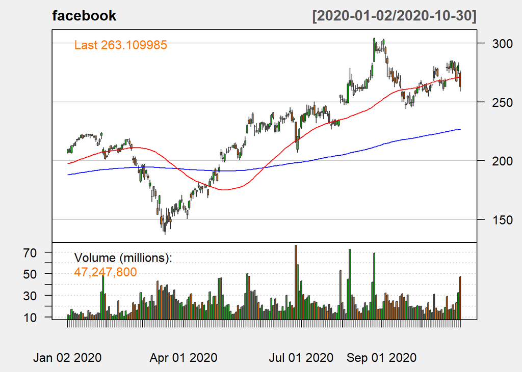

```r
# adding 200 and 50 day moving averages using SMA function.
facebook <- cbind(facebook, round(SMA(facebook$FB.Adjusted, 50),2))
facebook <- cbind(facebook,round(SMA(facebook$FB.Adjusted, 200),2))

candleChart(facebook, TA=c(addVo(),addSMA(n=200,col = 'blue'),addSMA(n=50,col = 'red')),  subset = '2020-01::2020-10', theme = "white")
```

**In this chart we are using a longer period of time to see how moving averages lines behave over a time period. Red line is a 50 day MA and blue line is 200DMA. The 200-day moving average is considered especially significant in stock trading. As long as the 50-day moving average of a stock price remains above the 200-day moving average, the stock is generally thought to be in a upward trend. A crossover to the downside of the 200-day moving average is interpreted as downward trend. here is the link to learn more about Moving averages https://www.investopedia.com/ask/answers/122414/what-are-most-common-periods-used-creating-moving-average-ma-lines.asp**

## Relative Strength Index (RSI)

#### The relative strength index (RSI) is a momentum indicator used in technical analysis that measures the magnitude of recent price changes to evaluate overbought or oversold conditions in the price of a stock or other asset. RSI values are from 0 to 100 Lets add Relative strength Indnex using a RSI function and viusalize it.

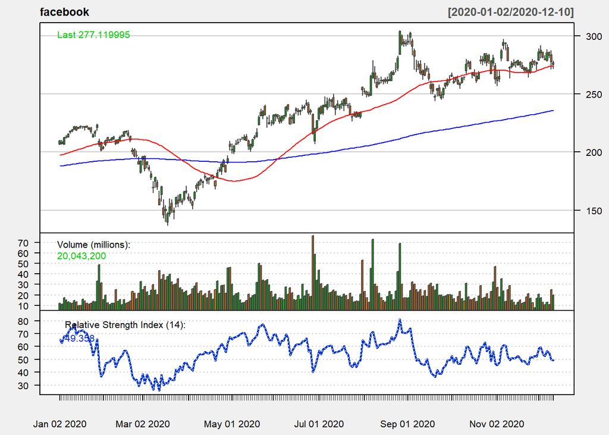

```r
facebook <- cbind(facebook, round(RSI(facebook$FB.Adjusted),2))

candleChart(facebook, TA=c(addVo(), addSMA(n=200,col = 'blue'), addSMA(n=50,col = 'red'), addRSI(n=14)),  subset = '2020-01::2020-12', theme = "white")
```

**Technical traders use the center-line to show shifts in the trend. If RSI is above 50, momentum is considered up and traders can look for opportunities to buy the market. A drop below 50 would indicate the development of a new bearish market trend. here is a link to learn more about RSI indicator https://www.investopedia.com/articles/active-trading/042114/overbought-or-oversold-use-relative-strength-index-find-out.asp**

## Bollingers Bands

#### Bollinger Bands are a technical indicator that forms a channel around the price movements of an asset. Bollinger bands have three lines, an upper, middle and lower. The middle line is a moving average of prices, the upper and lower bands are drawn on either side of the moving average. The distance between the upper and lower band is determined by standard deviations. The trader determines how many standard deviations they want the indicator set at, although many use two standard deviations from the average. Lets add Bolliner bands and visualize it.

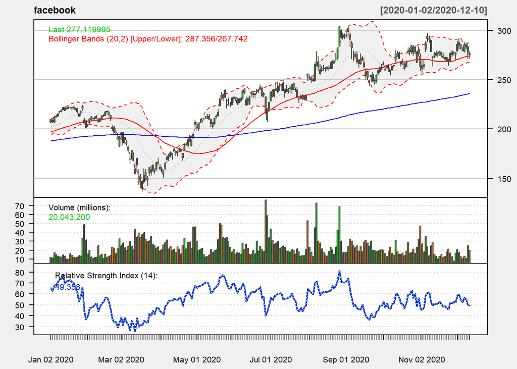

```r
facebook <- cbind(facebook,round(BBands(HLC(facebook)),2))

candleChart(facebook, TA=c(addVo(),addSMA(n=200,col = 'blue'),addSMA(n=50,col = 'red'), addRSI(n=14),addBBands()),  subset = '2020-01::2020-12', theme = "white")
```

**Red doted lines around the candlesticks are upper and lower bounds. Gray dotted line is the average. by default, average is 20SMA and bounds are average +-2 standard deviation. Traders tend to buy over the average and sell below.**

## Data cleaning and Transforming

#### In order to run our logistic regression, we need to find the the percentage difference of previous close and the next day open. here is how it works, ((open - previous close)/open) * 100.

```r
# rename the column names so we can see it better.
colnames(facebook) <- c("Open", "High", "Low", "Close", "Volume", "Adjusted", "200DMA", "50DMA", "RSI","Lower-bound","Mavg","Upper-bound", "PctB")

head(facebook)
```

```
##             Open  High   Low Close    Volume Adjusted 200DMA 50DMA RSI
## 2013-01-02 27.44 28.18 27.42 28.00  69846400    28.00     NA    NA  NA
## 2013-01-03 27.88 28.47 27.59 27.77  63140600    27.77     NA    NA  NA
## 2013-01-04 28.01 28.93 27.83 28.76  72715400    28.76     NA    NA  NA
## 2013-01-07 28.69 29.79 28.65 29.42  83781800    29.42     NA    NA  NA
## 2013-01-08 29.51 29.60 28.86 29.06  45871300    29.06     NA    NA  NA
## 2013-01-09 29.67 30.60 29.49 30.59 104787700    30.59     NA    NA  NA
##            Lower-bound Mavg Upper-bound PctB
## 2013-01-02          NA   NA          NA   NA
## 2013-01-03          NA   NA          NA   NA
## 2013-01-04          NA   NA          NA   NA
## 2013-01-07          NA   NA          NA   NA
## 2013-01-08          NA   NA          NA   NA
## 2013-01-09          NA   NA          NA   NA
```

```r
## because over 200 day moving average column needed previous 200 days worth of data to calculate 200 DMA, it will show nan values in first 200 days. we can delete those rows so we dont have any NA values.

facebook <- facebook[-(1:200), drop = FALSE]

head(facebook)
```

```
##             Open  High   Low Close   Volume Adjusted 200DMA 50DMA   RSI
## 2013-10-17 51.12 52.22 50.95 52.21 71522000    52.21  44.43 31.73 67.53
## 2013-10-18 54.18 54.83 53.60 54.22 88260000    54.22  44.74 31.86 72.04
## 2013-10-21 54.68 54.81 53.51 53.85 58235000    53.85  45.05 31.99 70.11
## 2013-10-22 54.33 54.76 52.20 52.68 83204000    52.68  45.34 32.10 64.25
## 2013-10-23 51.75 52.25 51.13 51.90 57207000    51.90  45.64 32.22 60.61
## 2013-10-24 52.38 52.84 51.59 52.45 46775000    52.45  45.95 32.33 62.24
##            Lower-bound  Mavg Upper-bound PctB
## 2013-10-17       46.71 49.48       52.25 0.92
## 2013-10-18       46.62 49.84       53.06 1.18
## 2013-10-21       46.76 50.19       53.63 1.06
## 2013-10-22       46.81 50.42       54.02 0.89
## 2013-10-23       46.94 50.55       54.15 0.67
## 2013-10-24       46.98 50.65       54.33 0.72
```

```r
## check data class

class(facebook)
```

```
## [1] "xts" "zoo"
```

```r
# convert variable data type to dataframe.
fb <- as.data.frame(facebook)
# add column name for the date column
fb <- cbind(date=row.names(fb),fb)
## Add a new column to dataframe
fb <-  mutate(fb, Percent_Difference = ((lead(fb$Open) - fb$Adjusted)/lead(fb$Open)*100))
## round up your percentage
fb$Percent_Difference <- round(fb$Percent_Difference,2)
## move down your differences so we can allign with the correct date.
fb$Percent_Difference <- shift(fb$Percent_Difference,1)
fb$`200DMA` <- shift(fb$`200DMA`,1)
fb$`50DMA` <- shift(fb$`50DMA`,1)
fb$RSI <- shift(fb$RSI,1)
fb$`Lower-bound` <- shift(fb$`Lower-bound`,1)
fb$Mavg <- shift(fb$Mavg,1)
fb$`Upper-bound` <- shift(fb$`Upper-bound`,1)
fb$PctB <- shift(fb$PctB,1)
head(fb)
```

```
##         date  Open  High   Low Close   Volume Adjusted 200DMA 50DMA   RSI
## 1 2013-10-17 51.12 52.22 50.95 52.21 71522000    52.21     NA    NA    NA
## 2 2013-10-18 54.18 54.83 53.60 54.22 88260000    54.22  44.43 31.73 67.53
## 3 2013-10-21 54.68 54.81 53.51 53.85 58235000    53.85  44.74 31.86 72.04
## 4 2013-10-22 54.33 54.76 52.20 52.68 83204000    52.68  45.05 31.99 70.11
## 5 2013-10-23 51.75 52.25 51.13 51.90 57207000    51.90  45.34 32.10 64.25
## 6 2013-10-24 52.38 52.84 51.59 52.45 46775000    52.45  45.64 32.22 60.61
##   Lower-bound  Mavg Upper-bound PctB Percent_Difference
## 1          NA    NA          NA   NA                 NA
## 2       46.71 49.48       52.25 0.92               3.64
## 3       46.62 49.84       53.06 1.18               0.84
## 4       46.76 50.19       53.63 1.06               0.88
## 5       46.81 50.42       54.02 0.89              -1.80
## 6       46.94 50.55       54.15 0.67               0.92
```

```r
fb["Win/Loss"] <- ifelse(fb$High >  shift(fb$Close) & fb$Percent_Difference < 0 ,1, 0)
fb["MA50"] <- ifelse(fb$Open > fb$`50DMA`,"Above","Below")
fb["MA200"] <- ifelse(fb$Open > fb$`200DMA`,"Above","Below")
fb["RSI_ind"] <- ifelse(fb$RSI > 30 & fb$RSI < 70, "Above", "Below")
fb["BBavg"] <- ifelse(fb$Open > fb$Mavg, "Above","Below")
 ## since we are only concern with the days where stock opened lower than previous close, we will use filter to get negative values in percent_Difference column.

filter_data <- dplyr::filter(fb, Percent_Difference < 0)
```

#### Here is a function that will do all the steps we just did for any ticker.

```r
## creating a function that can get any stock price from a given time period and create columns that we need for analysis.

FAANG <- function(ticker){
  current_date <- format(Sys.time(), "%Y-%m-%d")

  stock_data <- getSymbols(ticker, src = "yahoo", from = "2013-01-01", to = current_date, auto.assign = FALSE)
  colnames(stock_data) <- c("Open", "High", "Low", "Close", "Volume", "Adjusted")
  stock_data <- cbind(stock_data, round(SMA(stock_data$Adjusted, 50),2))
  stock_data <- cbind(stock_data, round(SMA(stock_data$Adjusted, 200),2))
  stock_data <- cbind(stock_data, round(RSI(stock_data$Adjusted),2))
  stock_data <- cbind(stock_data, round(BBands(HLC(stock_data)),2))
  colnames(stock_data) <- c("Open", "High", "Low", "Close", "Volume", "Adjusted", "200DMA", "50DMA",   "RSI","Lower-bound","Mavg","Upper-bound", "PctB")
  stock_data <-  stock_data[-(1:200), drop = FALSE]
  stock_data <- as.data.frame(stock_data)
  stock_data <- cbind(date=row.names(stock_data),stock_data)
  stock_data <-  mutate(stock_data, Percent_Difference = ((lead(stock_data$Open) - stock_data$Adjusted)/lead(stock_data$Open)*100))
  stock_data$Percent_Difference <- round(stock_data$Percent_Difference,2)
  stock_data$Percent_Difference <- shift(stock_data$Percent_Difference,1)
  stock_data$`200DMA` <- shift(stock_data$`200DMA`,1)
  stock_data$`50DMA` <- shift(stock_data$`50DMA`,1)
  stock_data$RSI <- shift(stock_data$RSI,1)
  stock_data$`Lower-bound` <- shift(stock_data$`Lower-bound`,1)
  stock_data$Mavg <- shift(stock_data$Mavg,1)
  stock_data$`Upper-bound` <- shift(stock_data$`Upper-bound`,1)
  stock_data$PctB <- shift(stock_data$PctB,1)
  stock_data["Win/Loss"] <- ifelse(stock_data$High >  shift(stock_data$Close) & stock_data$Percent_Difference < 0 ,1, 0 )
  stock_data["MA50"] <- ifelse(stock_data$Open > stock_data$`50DMA`,"Above","Below")
  stock_data["MA200"] <- ifelse(stock_data$Open > stock_data$`200DMA`,"Above","Below")
  stock_data["RSI_ind"] <- ifelse(stock_data$RSI > 30 & stock_data$RSI < 70, "Above", "Below")
  stock_data["BBavg"] <- ifelse(stock_data$Open > stock_data$Mavg, "Above","Below")
  stock_data <- dplyr::filter(stock_data, Percent_Difference < 0)
  stock_data <- stock_data[,c(1,14,15,16,17,18,19,20)]
  return(stock_data)
}

## since we are interested in FAANG stocks, we will only use these stock and we will filter the data to keep only relevant columns.
facebook <- FAANG("FB")
Amazon <- FAANG("AMZN")
Apple <- FAANG("AAPL")
Netflix <- FAANG("NFLX")
Google <- FAANG("GOOG")

head(facebook)
```

```
##         date PctB Percent_Difference Win/Loss  MA50 MA200 RSI_ind BBavg
## 1 2013-10-23 0.89              -1.80        0 Above Above   Above Above
## 2 2013-10-28 0.72              -0.80        0 Above Above   Above Above
## 3 2013-10-31 0.33              -3.92        1 Above Above   Above Below
## 4 2013-11-04 0.48              -0.77        0 Above Above   Above Below
## 5 2013-11-05 0.26              -0.90        1 Above Above   Above Below
## 6 2013-11-11 0.12              -1.04        0 Above Below   Above Below
```

Let’s check the logistics regression and measure mean to check how well it would predict.

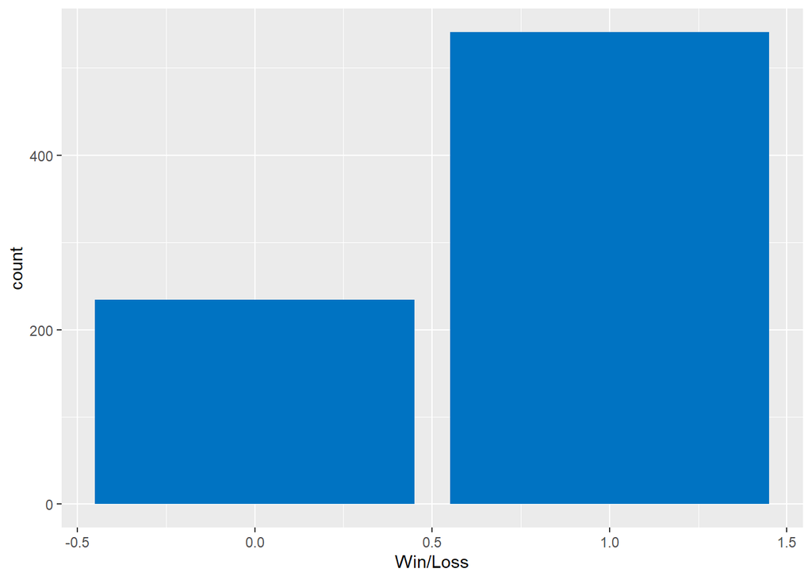

```r
ggplot(facebook, aes(`Win/Loss`)) +
  geom_bar(fill = "#0073C2FF")
```

```r
table(facebook$`Win/Loss`)
```

```
##
##   0   1
## 234 541
```

```r
glm.fits <- glm(`Win/Loss`~ Percent_Difference + RSI_ind , data = facebook  ,family="binomial")
summary(glm.fits)
```

```
##
## Call:
## glm(formula = `Win/Loss` ~ Percent_Difference + RSI_ind, family = "binomial",
##     data = facebook)
##
## Deviance Residuals:
##     Min       1Q   Median       3Q      Max
## -1.9282  -0.8750   0.6161   0.7442   2.5428
##
## Coefficients:
##                    Estimate Std. Error z value Pr(>|z|)
## (Intercept)          1.7685     0.1311  13.492   <2e-16 ***
## Percent_Difference   1.1272     0.1263   8.922   <2e-16 ***
## RSI_indBelow        -0.6099     0.2785  -2.190   0.0285 *
## ---
## Signif. codes:  0 '***' 0.001 '**' 0.01 '*' 0.05 '.' 0.1 ' ' 1
##
## (Dispersion parameter for binomial family taken to be 1)
##
##     Null deviance: 949.37  on 774  degrees of freedom
## Residual deviance: 820.41  on 772  degrees of freedom
## AIC: 826.41
##
## Number of Fisher Scoring iterations: 5
```

```r
glm.probs = predict(glm.fits, type = "response")

glm.pred = rep(0, length(glm.probs))
glm.pred[glm.probs > .5] = 1
table(glm.pred, facebook$`Win/Loss`)
```

```
##
## glm.pred   0   1
##        0  72  28
##        1 162 513
```

```r
mean(glm.pred == facebook$`Win/Loss`)
```

```
## [1] 0.7548387
```

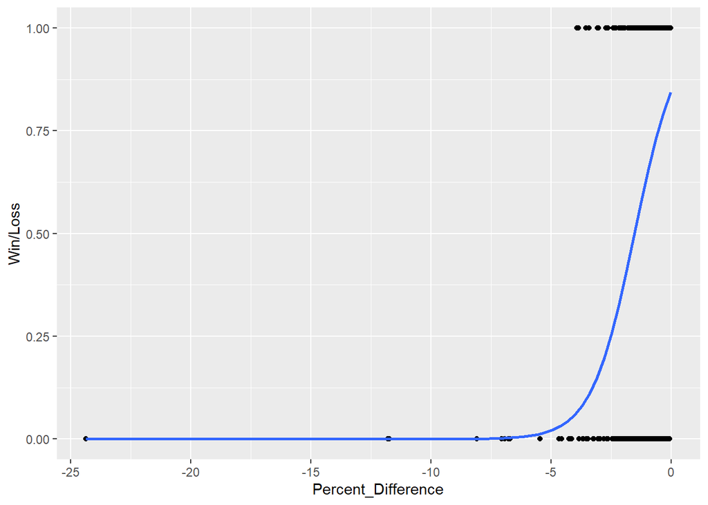

```r
ggplot(facebook, aes(x=Percent_Difference, y=`Win/Loss`)) + geom_point() + stat_smooth(method="glm", method.args=list(family="binomial"), se=FALSE)
```

**The mean value is around 76%, which is better than a random guess. So it’s evident that the prediction using logistics regression can give us better results than random guessing.**

## Logistic regression diagnostics

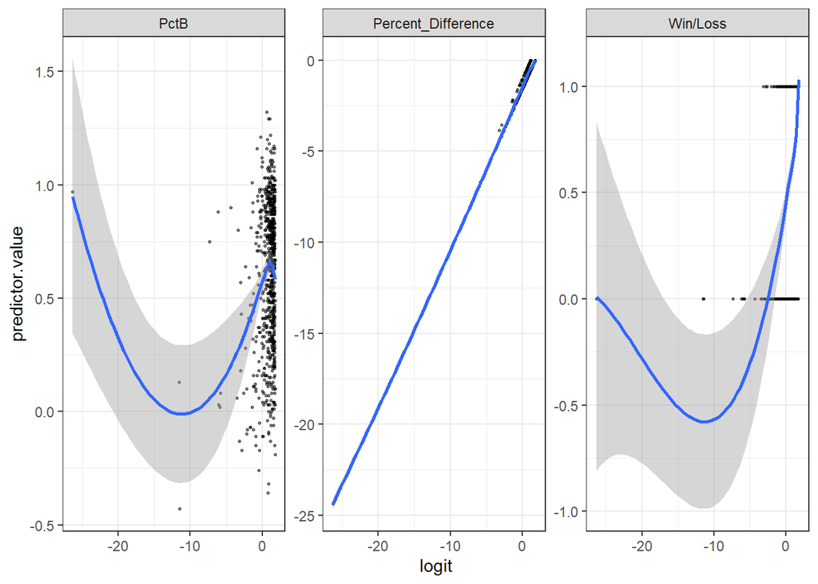

```r
# Select only numeric predictors
mydata <- facebook %>%
  dplyr::select_if(is.numeric)
predictors <- colnames(mydata)
# Bind the logit and tidying the data for plot
mydata <- mydata %>%
  mutate(logit = log(glm.probs/(1-glm.probs))) %>%
  gather(key = "predictors", value = "predictor.value", -logit)

ggplot(mydata, aes(logit, predictor.value))+
  geom_point(size = 0.5, alpha = 0.5) +
  geom_smooth(method = "loess") +
  theme_bw() +
  facet_wrap(~predictors, scales = "free_y")
```

**PctB which is a percent measure of Bollinger bands, shows non-linearity. Win/loss is binary so we dont have to worry about that**

#### Lets see variance inflation factor(VIF) for multicollinearity in regression analysis.

```r
vif(glm.fits)
```

```
## Percent_Difference            RSI_ind
##           1.006816           1.006816
```

**it looks ok as non of the independent variables VIF values are above 5**

#### Let’s test it using training-test data split and ascertain how well can it predict test data using training data. We use data upto 2016 for training and rest for testing.

```r
train=(facebook$date<2016) ## index of the training set

new_model <- glm(`Win/Loss`~Percent_Difference + PctB, data = facebook,subset = train, family="binomial")
summary(new_model)
```

```
##
## Call:
## glm(formula = `Win/Loss` ~ Percent_Difference + PctB, family = "binomial",
##     data = facebook, subset = train)
##
## Deviance Residuals:
##     Min       1Q   Median       3Q      Max
## -2.1351  -0.8051   0.6325   0.7418   1.9767
##
## Coefficients:
##                    Estimate Std. Error z value Pr(>|z|)
## (Intercept)          2.5131     0.4904   5.125 2.98e-07 ***
## Percent_Difference   0.9988     0.2397   4.167 3.09e-05 ***
## PctB                -1.2081     0.5825  -2.074   0.0381 *
## ---
## Signif. codes:  0 '***' 0.001 '**' 0.01 '*' 0.05 '.' 0.1 ' ' 1
##
## (Dispersion parameter for binomial family taken to be 1)
##
##     Null deviance: 266.70  on 230  degrees of freedom
## Residual deviance: 240.89  on 228  degrees of freedom
## AIC: 246.89
##
## Number of Fisher Scoring iterations: 5
```

```r
fb_2016 <- facebook[!train, ]
winloss_2016 <- facebook$`Win/Loss`[!train]

predicted_probs <- predict(new_model, newdata = fb_2016, type = "response")

predicted_dir <- rep(0, length(predicted_probs))
predicted_dir[predicted_probs > 0.5] <- 1

table(predicted_dir, winloss_2016)
```

```
##              winloss_2016
## predicted_dir   0   1
##             0  45  13
##             1 128 358
```

```r
mean(predicted_dir == winloss_2016)
```

```
## [1] 0.7408088
```

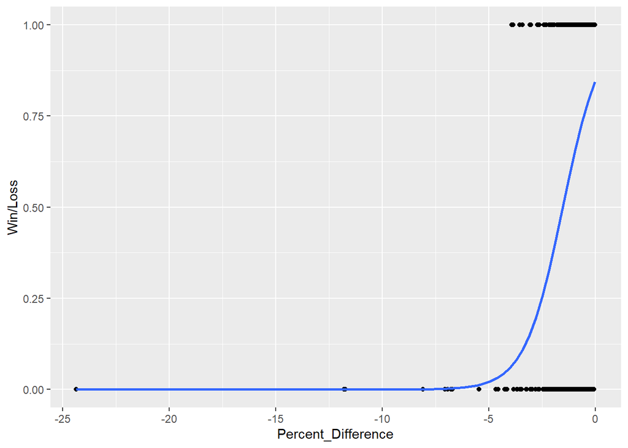

```r
ggplot(facebook, aes(x=Percent_Difference, y=`Win/Loss`)) + geom_point() + stat_smooth(method="glm", method.args=list(family="binomial"), se=FALSE)
```

**The mean value for test data using training data is around 74%, which is better than a random guess, so it’s evident that the model is able to predict well.**